# Counties: SVI + Karen Short + SIT-209 + Perimeters

##### 2020-05-01

```r
# Libraries
library(tidyverse)
library(sf)
library(tidycensus)
library(dbplyr)

# Parameters

## All historical perimeters
file_geomac <- here::here("data-raw", "US_HIST_FIRE_PERIMTRS_DD83", "US_HIST_FIRE_PERIMTRS_DD83.shp")

## County SVI data
## Source: https://svi.cdc.gov/data-and-tools-download.html
## 2000 SVI - only tract level available
# file_svi_2000 <- here::here("data-raw", "SVI2000_US.csv")

# Source: https://ephtracking.cdc.gov/DataExplorer/?query=779a2b45-2309-4b81-a2d7-8040b78969a0
## 2010, 2014, 2016
file_svi_2010_14_16 <- here::here("data-raw", "EPHTN_M604_D_183208", "data_183209.csv")

## 2018 SVI
file_svi_2018 <- here::here("data-raw", "SVI2018_US_COUNTY", "SVI2018_US_county.shp")

# Monitoring Trends in Burn Severity: Burned Areas Boundary Dataset
# Source: https://www.mtbs.gov/direct-download
# Download date: 2020-04-21
# Geography: United States
# Years: 2006 - 2017
file_mtbs <- here::here("data-raw", "mtbs_perimeter_data", "mtbs_perims_DD.shp")

## SIT-209
file_sit209 <- here::here("data-raw", "wildfires_deduped.csv")

#===============================================================================

# Code

# Read in the SIT-209 data
sit209 <-
  file_sit209 %>%
  read_csv(
    col_types =
      cols(
        .default = col_character(),
        LATITUDE = col_double(),
        LONGITUDE = col_double(),
        ESTIMATED_COST = col_double(),
        REPORT_DATE = col_datetime(format = ""),
        MAX_PERSONNEL = col_double(),
        INCIDENT_AREA = col_double(),
        MAX_SFR_THREAT = col_double(),
        MAX_MFR_THREAT = col_double(),
        MAX_MU_THREAT = col_double(),
        MAX_COMM_THREAT = col_double(),
        MAX_OUTB_THREAT = col_double(),
        MAX_OTHER_THREAT = col_double(),
        SFR_DAMAGED = col_double(),
        MFR_DAMAGED = col_double(),
        MU_DAMAGED = col_double(),
        COMM_DAMAGED = col_double(),
        OTHER_DAMAGED = col_double(),
        SFR_DESTROYED = col_double(),
        MFR_DESTROYED = col_double(),
        MU_DESTROYED = col_double(),
        COMM_DESTROYED = col_double(),
        OUTB_DESTROYED = col_double(),
        OTHER_DESTROYED = col_double(),
        INJURIES = col_double(),
        FATALITIES = col_double(),
        REPORT_ID = col_character(),
        WILDFIRE = col_logical(),
        STATE_FIPS = col_character(),
        DESTROYED = col_logical(),
        THREATENED = col_logical(),
        CLIMATE_REGION = col_character()
      )
  )

# Read in the fire shapefile data
mtbs <-
  read_sf(file_mtbs)

## Read in the GEOMAC data

geomac <-
  read_sf(file_geomac)

## Read in the SVI data

svi_2010_14_16 <-
  read_sf(file_svi_2010_14_16)

svi_2018 <-
  read_sf(file_svi_2018)

# Connect to Karen Short's database
# Source: https://www.fs.usda.gov/rds/archive/catalog/RDS-2013-0009.4
con <-
  DBI::dbConnect(
    drv = RSQLite::SQLite(),
    dbname = here::here("data-raw", "RDS-2013-0009", "Data", "FPA_FOD_20170508.sqlite"),
  )

# Read the "Fires" table into a dataframe
karen <- DBI::dbReadTable(con, "Fires")

# Disconect the database
DBI::dbDisconnect(con)

# Get county geometries

counties <-
  ussf::boundaries(geography = c("county"), projection = c("longlat")) %>%
  st_transform(crs = 4269)
```

# Setup

## Join Karen Short’s data to SIT-209

```r
sit_karen <-
  sit209 %>%
  left_join(karen, by = c("INCIDENT_NUMBER" = "ICS_209_INCIDENT_NUMBER")) %>%
  drop_na(INCIDENT_NUMBER) %>%
  mutate(
    county_fips = as.character(str_glue("{STATE_FIPS}{FIPS_CODE}")),
    bin_year =
      # TODO: Revisit whether this binning scheme is legitimate
      case_when(
        REPORT_YEAR <= 2009 ~ -999,
        REPORT_YEAR <= 2012 ~ 2010,
        REPORT_YEAR <= 2014 ~ 2014,
        REPORT_YEAR <= 2016 ~ 2016,
        REPORT_YEAR <= 2018 ~ 2018
      ),
    year_fips = str_glue("{bin_year}_{county_fips}")
  )
```

## Join Karen + SIT-209 to MTBS (OR FIND GEOGRAPHY COLUMN in KAREN)

```r
sit_karen_mtbs <-
  sit_karen %>%
  left_join(mtbs, by = c("MTBS_ID" = "Fire_ID"))
```

Let’s see how this worked out.

We can see from the following that geometry is the most complete way to join to other data.

```r
sit_karen_mtbs %>%
  summarize_all(~ sum(is.na(.))) %>%
  select(STATE_FIPS, COUNTY.y, FIPS_CODE, FIPS_NAME, LATITUDE.x, LONGITUDE.x, geometry)
```

```
## # A tibble: 1 x 7
##   STATE_FIPS COUNTY.y FIPS_CODE FIPS_NAME LATITUDE.x LONGITUDE.x geometry
##        <int>    <int>     <int>     <int>      <int>       <int>    <int>
## 1          0    19384     19384     19384       1212        1195        0
```

But, then again, FIPS code is generally only missing in the case of fires where we lack lots of other information already, so including records without FIPS_CODE might only have limited added benefit.

```r
sit_karen_mtbs %>%
  filter(is.na(FIPS_CODE)) %>%
  summarise_all(~ sum(is.na(.)))
```

```
## # A tibble: 1 x 90
##   REPORT_YEAR FORM_TYPE INTERNAL_DB_ID INCIDENT_NUMBER INCIDENT_NAME
##         <int>     <int>          <int>           <int>         <int>
## 1           0         0          10393               0            17
## # … with 85 more variables: INCIDENT_TYPE <int>, STATE.x <int>, COUNTY.x <int>,
## #   LATITUDE.x <int>, LONGITUDE.x <int>, START_DATE <int>, END_DATE <int>,
## #   CAUSE <int>, ESTIMATED_COST <int>, REPORT_DATE <int>, MAX_PERSONNEL <int>,
## #   INCIDENT_AREA <int>, MAX_SFR_THREAT <int>, MAX_MFR_THREAT <int>,
## #   MAX_MU_THREAT <int>, MAX_COMM_THREAT <int>, MAX_OUTB_THREAT <int>,
## #   MAX_OTHER_THREAT <int>, SFR_DAMAGED <int>, MFR_DAMAGED <int>,
## #   MU_DAMAGED <int>, COMM_DAMAGED <int>, OTHER_DAMAGED <int>,
## #   SFR_DESTROYED <int>, MFR_DESTROYED <int>, MU_DESTROYED <int>,
## #   COMM_DESTROYED <int>, OUTB_DESTROYED <int>, OTHER_DESTROYED <int>,
## #   INJURIES <int>, FATALITIES <int>, REPORT_ID <int>, WILDFIRE <int>,
## #   STATE_FIPS <int>, DESTROYED <int>, THREATENED <int>, CLIMATE_REGION <int>,
## #   OBJECTID <int>, FOD_ID <int>, FPA_ID <int>, SOURCE_SYSTEM_TYPE <int>,
## #   SOURCE_SYSTEM <int>, NWCG_REPORTING_AGENCY <int>,
## #   NWCG_REPORTING_UNIT_ID <int>, NWCG_REPORTING_UNIT_NAME <int>,
## #   SOURCE_REPORTING_UNIT <int>, SOURCE_REPORTING_UNIT_NAME <int>,
## #   LOCAL_FIRE_REPORT_ID <int>, LOCAL_INCIDENT_ID <int>, FIRE_CODE <int>,
## #   FIRE_NAME <int>, ICS_209_NAME <int>, MTBS_ID <int>, MTBS_FIRE_NAME <int>,
## #   COMPLEX_NAME <int>, FIRE_YEAR <int>, DISCOVERY_DATE <int>,
## #   DISCOVERY_DOY <int>, DISCOVERY_TIME <int>, STAT_CAUSE_CODE <int>,
## #   STAT_CAUSE_DESCR <int>, CONT_DATE <int>, CONT_DOY <int>, CONT_TIME <int>,
## #   FIRE_SIZE <int>, FIRE_SIZE_CLASS <int>, LATITUDE.y <int>,
## #   LONGITUDE.y <int>, OWNER_CODE <int>, OWNER_DESCR <int>, STATE.y <int>,
## #   COUNTY.y <int>, FIPS_CODE <int>, FIPS_NAME <int>, Shape <int>,
## #   county_fips <int>, bin_year <int>, year_fips <int>, Fire_Name <int>,
## #   Year <int>, StartMonth <int>, StartDay <int>, Fire_Type <int>, Acres <int>,
## #   geometry <int>
```

```r
sit_karen_mtbs %>%
  count(is.na(FIPS_CODE), is.na(COUNTY.x), is.na(COUNTY.y))
```

```
## # A tibble: 4 x 4
##   `is.na(FIPS_CODE)` `is.na(COUNTY.x)` `is.na(COUNTY.y)`     n
##   <lgl>              <lgl>             <lgl>             <int>
## 1 FALSE              FALSE             FALSE             16221
## 2 FALSE              TRUE              FALSE              1870
## 3 TRUE               FALSE             TRUE              16682
## 4 TRUE               TRUE              TRUE               2702
```

## Count points in polygon

- Get centroids of each fire

```r
centroids <-
  sit_karen_mtbs %>%
  mutate(centroid = st_centroid(geometry))
```

- Join to all county geographies

```r
#TODO: CHECK THAT THIS WORKED
#TODO: Count the points in the actual polygons
centroids_counties <-
  centroids %>%
  st_as_sf() %>%
  st_join(counties, join = st_within)
```

```
## although coordinates are longitude/latitude, st_within assumes that they are planar
```

## Summarize fire counts, etc., by county

```r
county_summary <-
  sit_karen_mtbs %>%
  select(-Shape) %>%
  group_by(county_fips, REPORT_YEAR, year_fips, bin_year) %>%
  summarize(
    county_fires = n(),
    county_acres = sum(FIRE_SIZE, na.rm = TRUE),
    county_cost = sum(ESTIMATED_COST, na.rm = TRUE),
    county_homes_destroyed = sum(SFR_DESTROYED, na.rm = TRUE),
    county_homes_damaged = sum(SFR_DAMAGED, na.rm = TRUE),
    county_homes_threatened = sum(MAX_SFR_THREAT, na.rm = TRUE),
    county_personnel = sum(MAX_PERSONNEL, na.rm = TRUE),
    county_cost_per_acre = county_cost / county_acres,
    county_median_acres = median(FIRE_SIZE, na.rm = TRUE),
    county_median_cost = median(ESTIMATED_COST, na.rm = TRUE),
    destroyed_count = sum(DESTROYED, na.rm = TRUE),
    threatened_count = sum(THREATENED, na.rm = TRUE)
  ) %>%
  ungroup()
```

Note that each record in `county_summary` gives stats for a county in a given year.

## Join Karen + SIT-209 + MTBS to SVI by county. Remember to use the right SVI years

- Prepare the join by combining SVI into one dataframe and adding a new unique ID to join on.

We wrangle the 2018 data first to match the rest of the data.

```r
svi_2018_wrangled <-
  svi_2018 %>%
  mutate(
    Year = "2018",
    FIPS = as.double(FIPS),
    FIPS = as.character(FIPS),
    year_fips = str_glue("{Year}_{FIPS}")
  ) %>%
  select(
    "stateFIPS" = ST,
    "State" = STATE,
    "countyFIPS" = FIPS,
    "County" = COUNTY,
    Year,
    "Value" = RPL_THEMES,
    year_fips
  )
```

Then we wrangle the rest of the data a little.

```r
svi_10_14_16_wrangled <-
  svi_2010_14_16 %>%
  mutate(
    countyFIPS = as.double(countyFIPS),
    countyFIPS = as.character(countyFIPS),
    year_fips = str_glue("{Year}_{countyFIPS}"),
    Value = as.double(Value)
  ) %>%
  select(-`Data Comment`, -field_8)
```

Now we can combine the two.

```r
svi <-
  svi_10_14_16_wrangled %>%
  bind_rows(svi_2018_wrangled) %>%
  select(-geometry)
```

- FInally, join to the fires data

```r
fires_svi <-
  county_summary %>%
  filter(bin_year != -999) %>%
  mutate(year_fips = as.character(year_fips)) %>%
  left_join(svi, by = c("year_fips"))
```

## Bin counties by SVI

```r
fires_svi_binned <-
 fires_svi %>%
  mutate(
    bucket =
      case_when(
        Value == 1 ~ 1,
        Value > 0.95 ~ 0.95,
        Value > 0.9 ~ 0.9,
        Value > 0.85 ~ 0.85,
        Value > 0.8 ~ 0.8,
        Value > 0.75 ~ 0.75,
        Value > 0.7 ~ 0.7,
        Value > 0.65 ~ 0.65,
        Value > 0.6 ~ 0.6,
        Value > 0.55 ~ 0.55,
        Value > 0.5 ~ 0.5,
        Value > 0.45 ~ 0.45,
        Value > 0.4 ~ 0.4,
        Value > 0.35 ~ 0.35,
        Value > 0.3 ~ 0.3,
        Value > 0.25 ~ 0.25,
        Value > 0.2 ~ 0.2,
        Value > 0.15 ~ 0.15,
        Value > 0.1 ~ 0.1,
        Value > 0.05 ~ 0.05,
        Value > 0 ~ 0,
        Value == 0 ~ -0.05,
        TRUE ~ NA_real_
      )
  )
```

# Highlights from exploratory data analysis

Please regard the following as extremely preliminary. We’ll want to very carefully check the robustness of the relationships these plots seem to show. As you will find by looking at the next section, “More exploratory data analysis”, there are plenty of reasons to doubt these plots.

### Fires that threaten structures more-frequently burn more-vulnerable counties than less-vulnerable counties

In the following code chunk, I find the total number of fires that threatened structures in each SVI bucket.

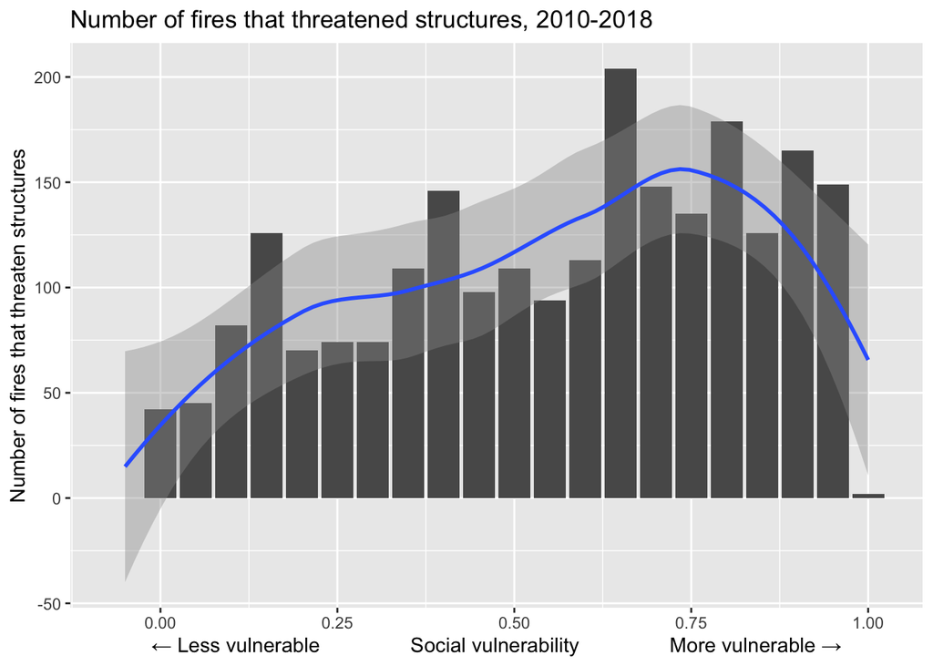

```r
fires_svi_binned %>%
  group_by(bucket) %>%
  summarize(n = sum(threatened_count)) %>%
  filter(n < 300) %>%
  ggplot(aes(x = bucket, y = n)) +
  geom_col(position = "dodge") +
  geom_smooth() +
  labs(
    title = "Number of fires that threatened structures, 2010-2018",
    x =
      "← Less vulnerable                Social vulnerability                More vulnerable →",
    y = "Number of fires that threaten structures"
  )
```

This plot suggests that there are genererally more fires that threatened structures in counties with higher SVI scores (as in, communities that are deemed more vulnerable) than in communities with lower SVI scores (which are deemed less vulnerable).

### Fires that destroyed structures hit more-vulnerable counties more frequently than less-vulnerable counties

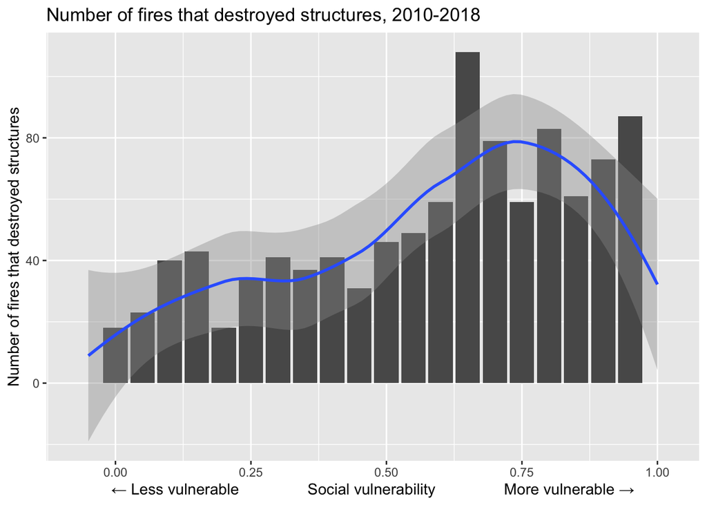

```r
fires_svi_binned %>%
  group_by(bucket) %>%
  summarize(n = sum(destroyed_count)) %>%
  filter(n < 200) %>%
  ggplot(aes(x = bucket, y = n)) +
  geom_col(position = "dodge") +
  geom_smooth() +
  labs(
    title = "Number of fires that destroyed structures, 2010-2018",
    x =
      "← Less vulnerable                Social vulnerability                More vulnerable →",
    y = "Number of fires that destroyed structures"
  )
```

### Fires in less-vulnerable places tend to be larger than fires in more-vulnerable places

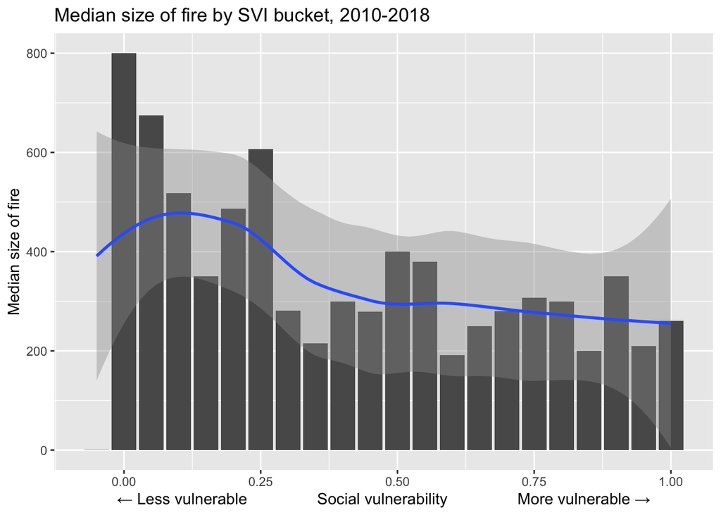

```r
fires_svi_binned %>%
  left_join(sit_karen_mtbs, by = c("year_fips")) %>%
  drop_na(bucket) %>%
  group_by(bucket) %>%
  summarize(
    median_acres = median(FIRE_SIZE, na.rm = TRUE)
  ) %>%
  ggplot(aes(x = bucket, y = median_acres)) +
  geom_col() +
  geom_smooth() +
    labs(
    title = "Median size of fire by SVI bucket, 2010-2018",
    x =
      "← Less vulnerable                Social vulnerability                More vulnerable →",
    y = "Median size of fire"
  )
```

### Fires in less-vulnerable places were more expensive per-acre than fires in more-vulnerable places (?)

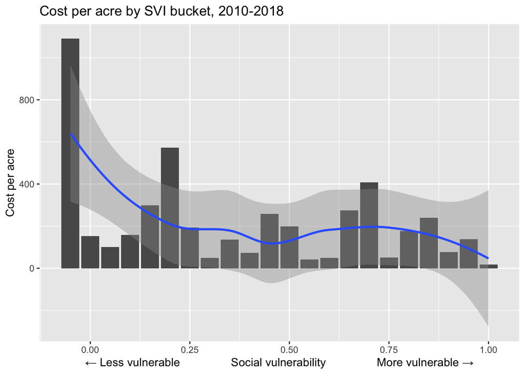

```r
fires_svi_binned %>%
  left_join(sit_karen_mtbs, by = c("year_fips")) %>%
  drop_na(bucket) %>%
  group_by(bucket) %>%
  summarize(
    cost = sum(ESTIMATED_COST, na.rm = TRUE),
    acres = sum(FIRE_SIZE, na.rm = TRUE)
  ) %>%
  filter(acres > 0) %>%
  mutate(cost_per_acre = cost / acres) %>%
  ggplot(aes(x = bucket, y = cost_per_acre)) +
  geom_col(position = "dodge") +
  geom_smooth() +
    labs(
    title = "Cost per acre by SVI bucket, 2010-2018",
    x =
      "← Less vulnerable                Social vulnerability                More vulnerable →",
    y = "Cost per acre"
  )
```

# More exploratory data analysis

## Costs per acre by SVI (bin and no bin)

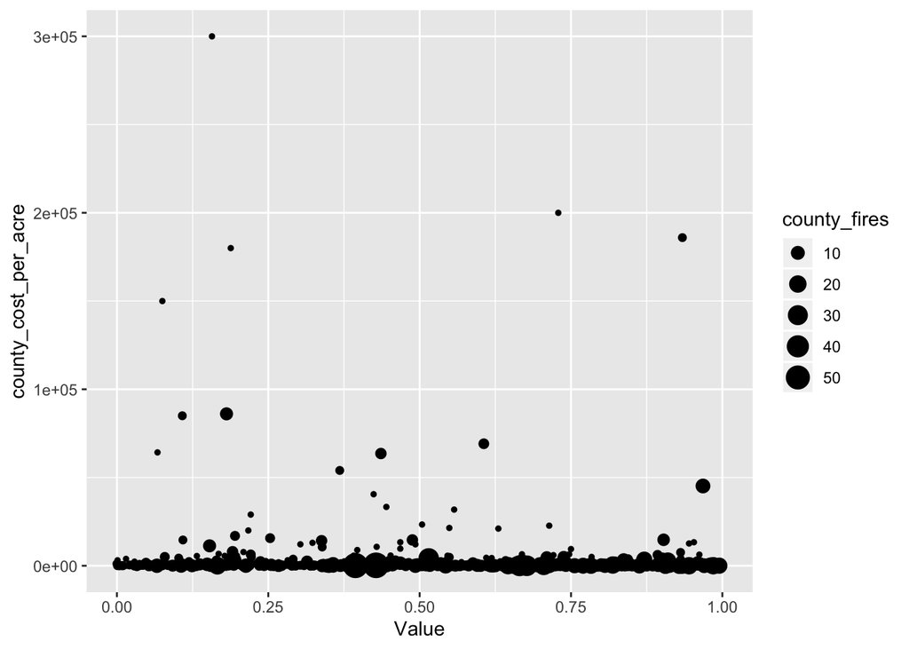

```r
fires_svi %>%
  drop_na(Value) %>%
  filter(
    county_cost > 0,
    county_cost_per_acre < 1e+06
  ) %>%
  ggplot() +
  geom_point(
    aes(
      x = Value,
      y = county_cost_per_acre,
      size = county_fires
    )
  )
```

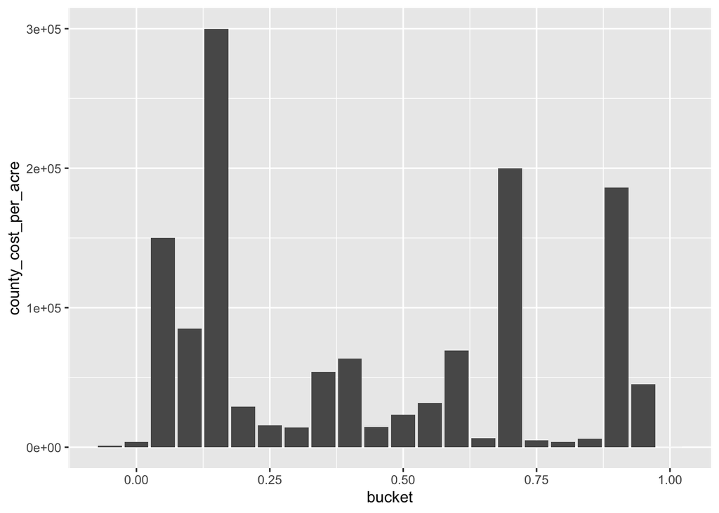

```r
fires_svi_binned %>%
  drop_na(Value) %>%
  filter(
    county_cost > 0,
    county_cost_per_acre < 1e+06
  ) %>%
  ggplot() +
  geom_col(aes(x = bucket, y = county_cost_per_acre), position = "dodge")
```

## Homes threatened

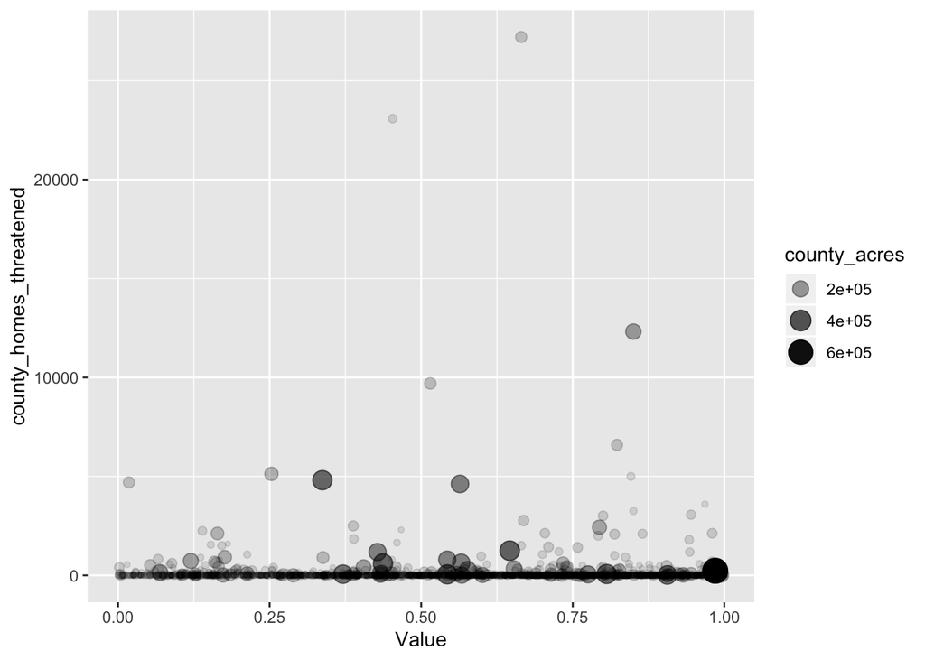

```r
fires_svi %>%
  drop_na(Value) %>%
  ggplot() +
  geom_point(
    aes(
      x = Value,
      y = county_homes_threatened,
      size = county_acres,
      alpha = county_acres
    )
  )
```

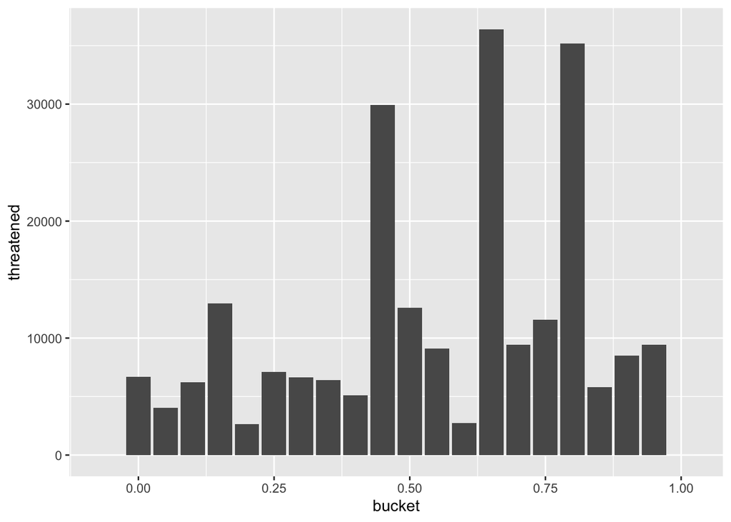

```r
fires_svi_binned %>%
  drop_na(Value) %>%
  group_by(bucket) %>%
  summarize(threatened = sum(county_homes_threatened, na.rm = TRUE)) %>%
  ggplot() +
  geom_col(aes(x = bucket, y = threatened), position = "dodge")
```

## Costs per house damaged or destroyed by SVI (bin and no bin)

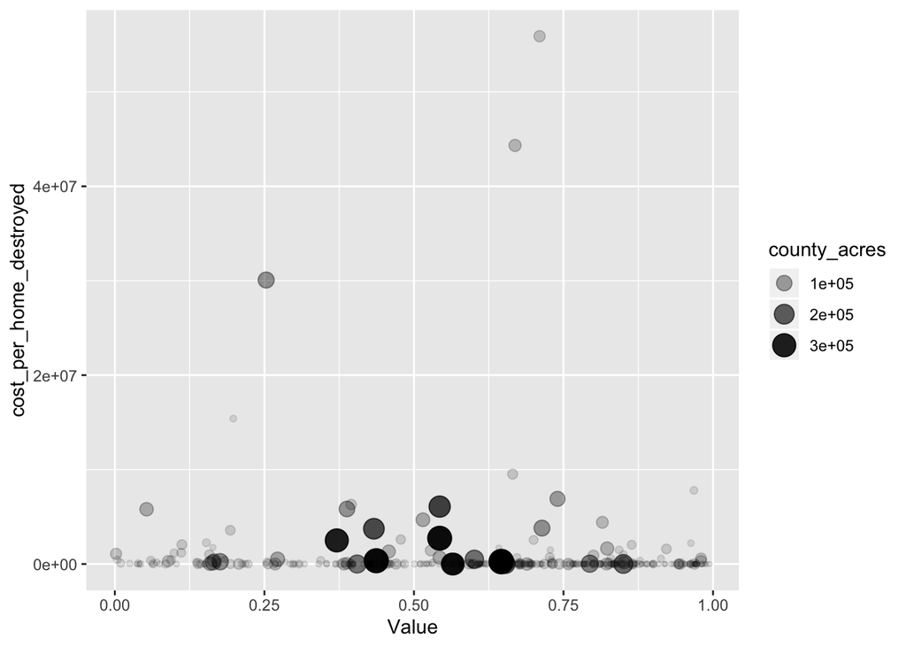

```r
fires_svi %>%
  drop_na(Value) %>%
  filter(county_homes_destroyed > 0) %>%
  mutate(cost_per_home_destroyed = county_cost / county_homes_destroyed) %>%
  ggplot() +
  geom_point(
    aes(
      x = Value,
      y = cost_per_home_destroyed,
      size = county_acres,
      alpha = county_acres
    )
  )
```

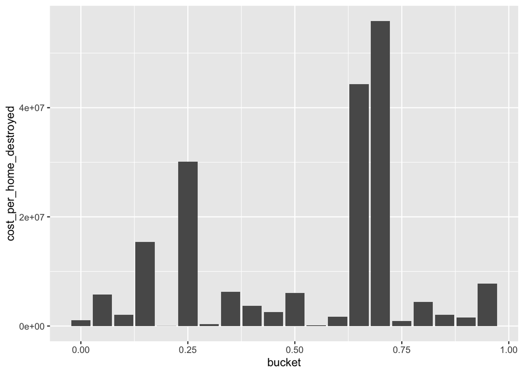

```r
fires_svi_binned %>%
  drop_na(Value) %>%
  filter(county_homes_destroyed > 0) %>%
  mutate(cost_per_home_destroyed = county_cost / county_homes_destroyed) %>%
  ggplot() +
  geom_col(aes(x = bucket, y = cost_per_home_destroyed), position = "dodge")
```

## Comparing medians

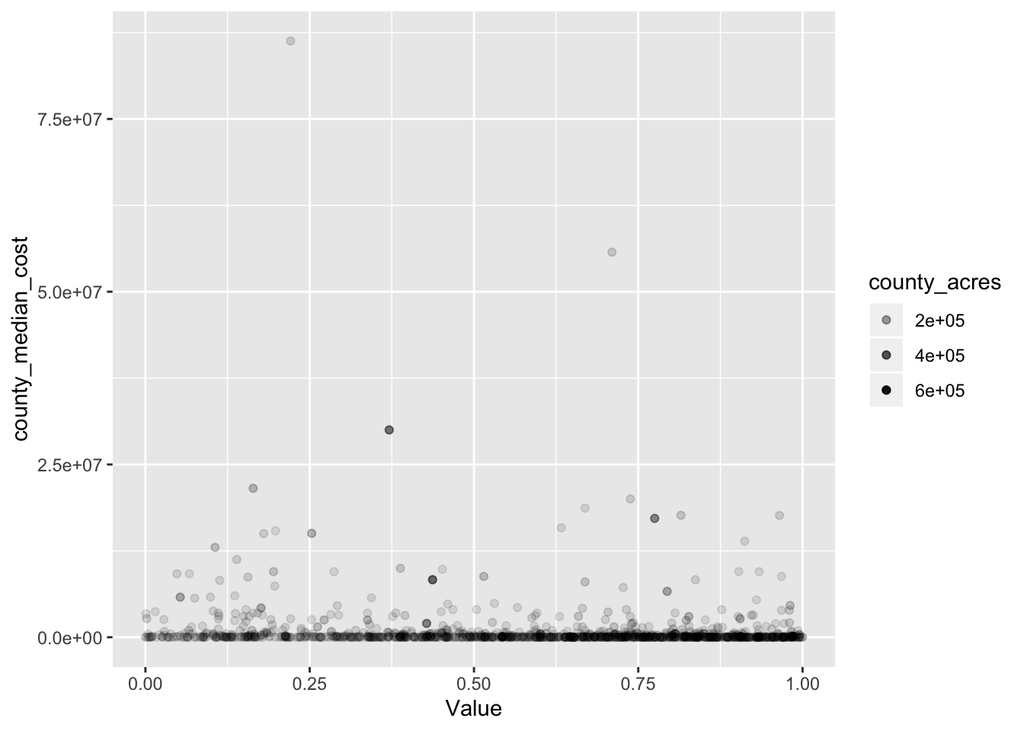

```r
fires_svi %>%
  drop_na(Value) %>%
  ggplot() +
  geom_point(
    aes(
      x = Value,
      y = county_median_cost,
      alpha = county_acres
    )
  )
```

## Total cost by bin

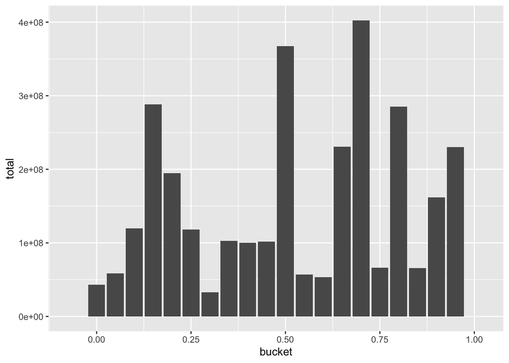

```r
fires_svi_binned %>%
  group_by(bucket) %>%
  summarize(total = sum(county_cost, na.rm = TRUE)) %>%
  ggplot() +
  geom_col(aes(y = total, x = bucket))
```

## Total acres burned by bin

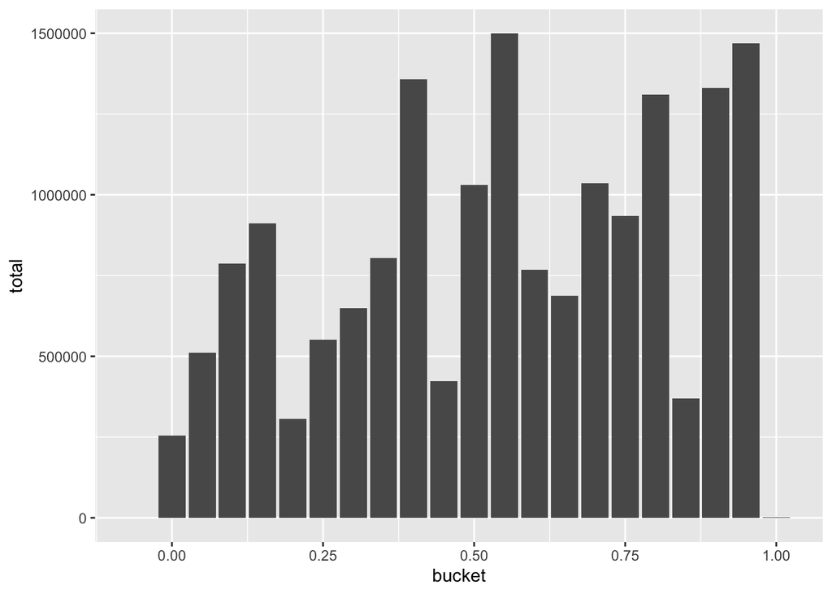

```r
fires_svi_binned %>%
  group_by(bucket) %>%
  summarize(total = sum(county_acres, na.rm = TRUE)) %>%
  ggplot() +
  geom_col(aes(y = total, x = bucket))
```

## Median total acres burned by bin

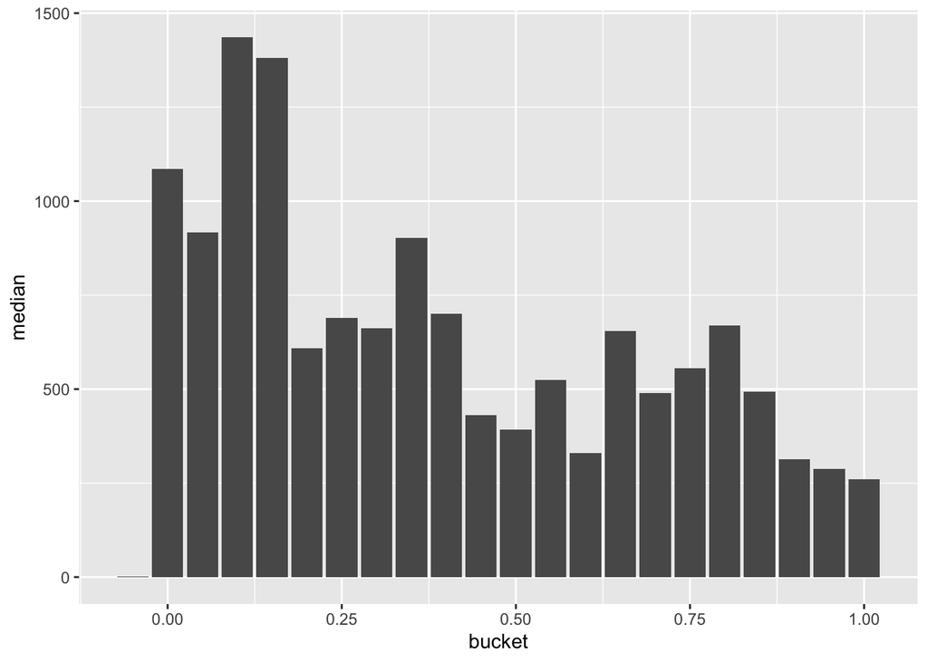

```r
fires_svi_binned %>%
  group_by(bucket) %>%
  summarize(median = median(county_acres, na.rm = TRUE)) %>%
  ggplot() +
  geom_col(aes(y = median, x = bucket))
```

## Mean total acres burned by bin

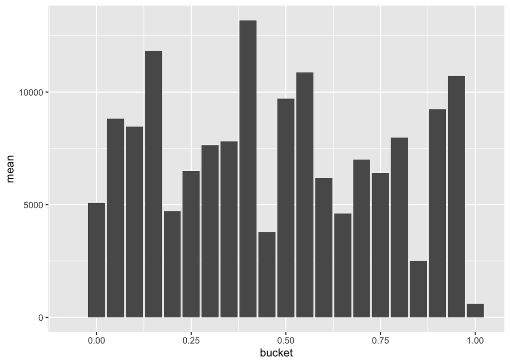

```r
fires_svi_binned %>%
  group_by(bucket) %>%
  summarize(mean = mean(county_acres, na.rm = TRUE)) %>%
  ggplot() +
  geom_col(aes(y = mean, x = bucket))
```

## Total destroyed by bin

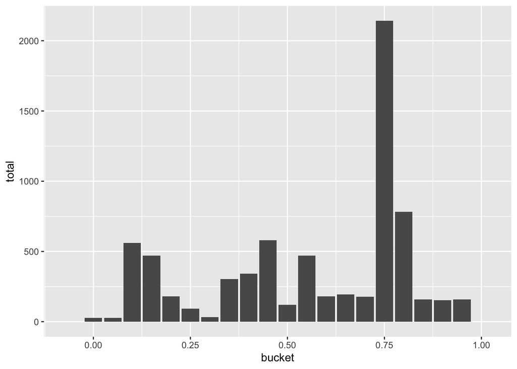

```r
fires_svi_binned %>%
  group_by(bucket) %>%
  summarize(total = sum(county_homes_destroyed, na.rm = TRUE)) %>%
  ggplot() +
  geom_col(aes(y = total, x = bucket))
```

## Ratio of total cost to homes destroyed by bin

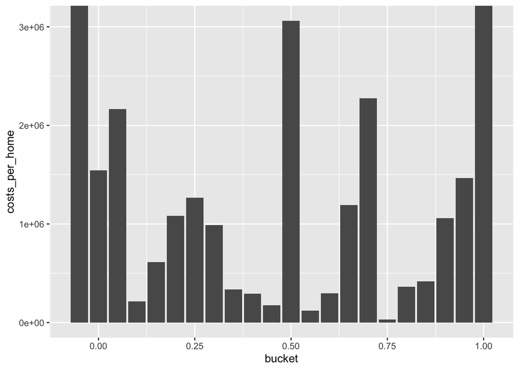

```r
fires_svi_binned %>%
  group_by(bucket) %>%
  summarize(
    homes_destroyed = sum(county_homes_destroyed, na.rm = TRUE),
    costs = sum(county_cost, na.rm = TRUE),
    costs_per_home = costs / homes_destroyed
  ) %>%
  ggplot() +
  geom_col(aes(y = costs_per_home, x = bucket))
```

Ignore the infinity values.

## Ratio of total cost to homes threatened by bin

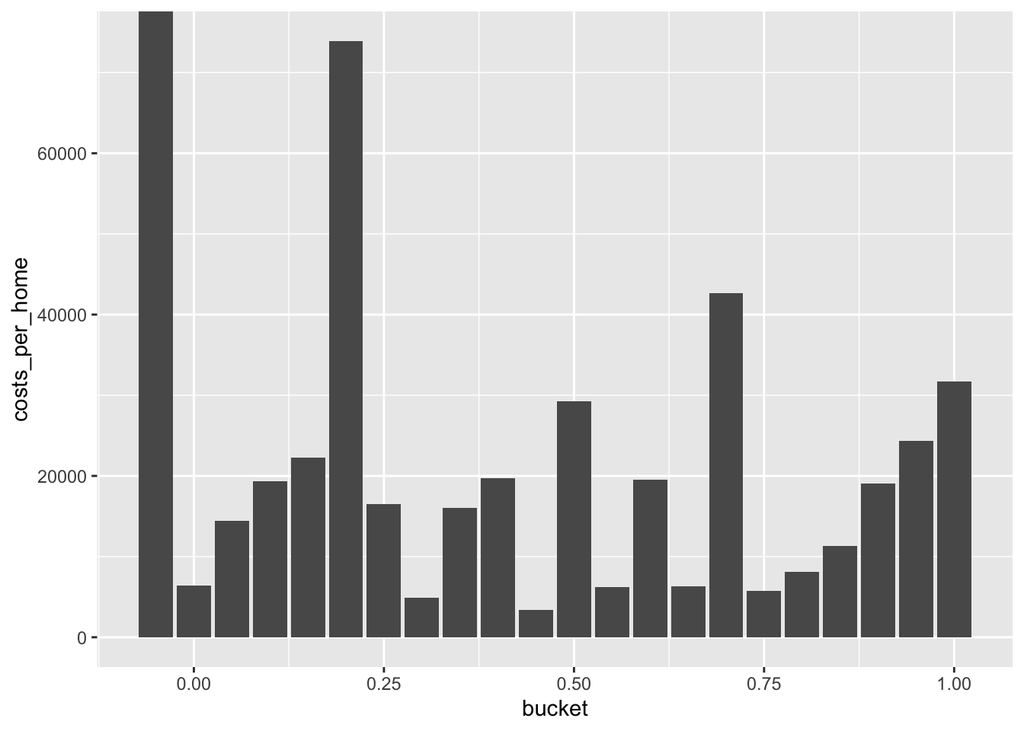

```r
fires_svi_binned %>%
  group_by(bucket) %>%
  summarize(
    homes_threatened = sum(county_homes_threatened, na.rm = TRUE),
    costs = sum(county_cost, na.rm = TRUE),
    costs_per_home = costs / homes_threatened
  ) %>%
  ggplot() +
  geom_col(aes(y = costs_per_home, x = bucket))
```

Again, ignore the infinity value.

# Basic EDA

## Typical size of all fires

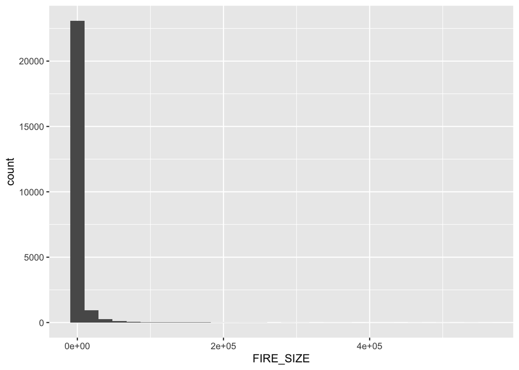

```r
sit_karen_mtbs %>%
  ggplot() +
  geom_histogram(aes(FIRE_SIZE))
```

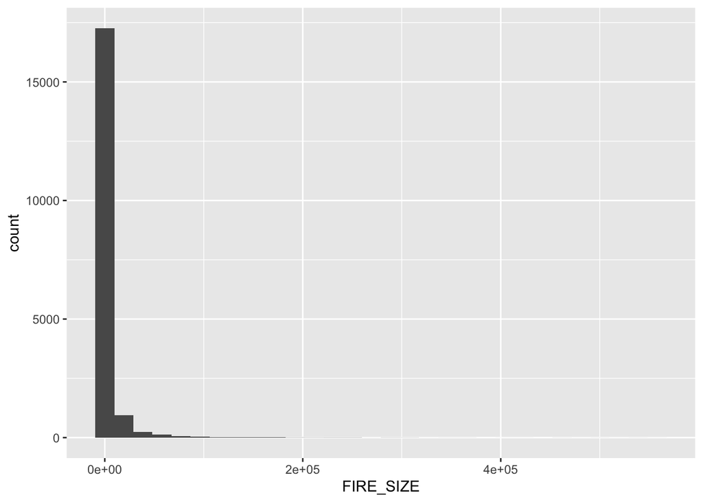

```r
sit_karen_mtbs %>%
  filter(FIRE_SIZE > 100) %>%
  ggplot() +
  geom_histogram(aes(FIRE_SIZE))
```

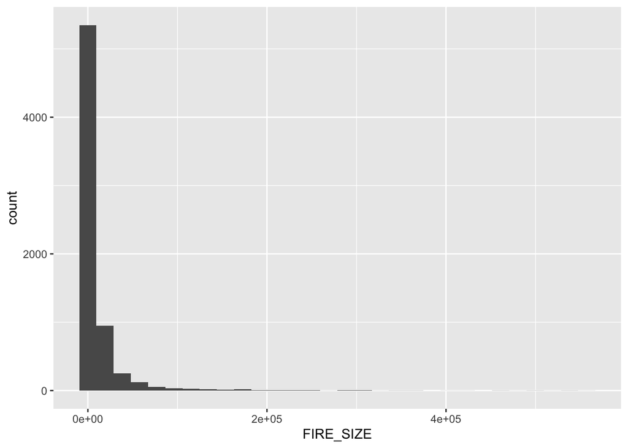

```r
sit_karen_mtbs %>%
  filter(FIRE_SIZE > 1000) %>%
  ggplot() +
  geom_histogram(aes(FIRE_SIZE))
```

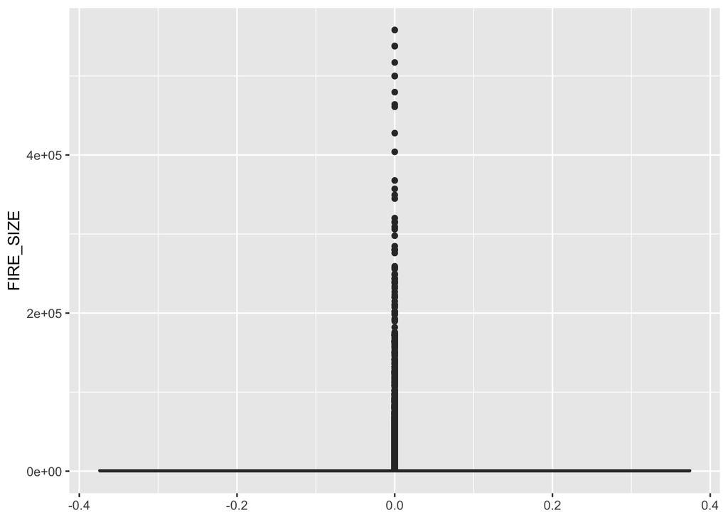

```r
sit_karen_mtbs %>%
  filter(FIRE_SIZE > 0) %>%
  ggplot() +
  geom_boxplot(aes(y = FIRE_SIZE))
```

## Typical size of fires by bin

[figure not shown]

```r
fires_svi_binned %>%
  ggplot() +
  geom_boxplot(aes(y = county_median_acres)) +
  facet_wrap(facets = vars(bucket))
```

## Typical number of fires in a county each year

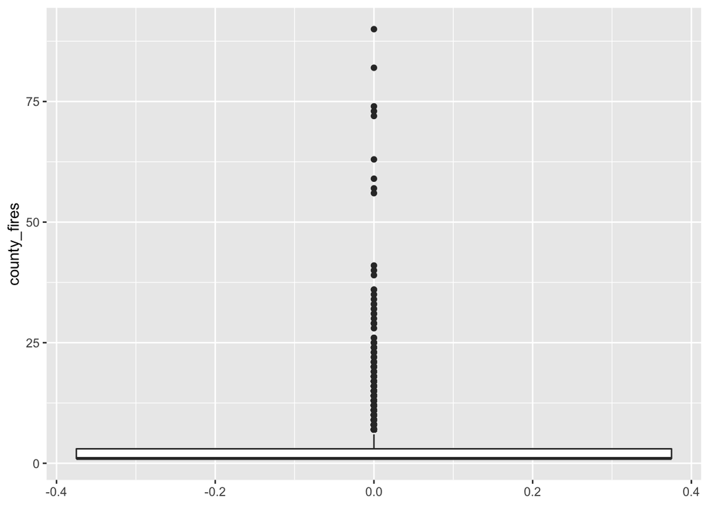

```r
county_summary %>%
  filter(!str_detect(county_fips, "NA")) %>%
  ggplot() +
  geom_boxplot(aes(y = county_fires))
```

```r
county_summary %>%
  filter(!str_detect(county_fips, "NA")) %>%
  arrange(desc(county_fires))
```

```
## # A tibble: 6,769 x 16
##    county_fips REPORT_YEAR year_fips bin_year county_fires county_acres
##    <chr>       <chr>       <glue>       <dbl>        <int>        <dbl>
##  1 16049       2006        -999_160…     -999           90      133211.
##  2 6105        2008        -999_6105     -999           82      270179.
##  3 16049       2003        -999_160…     -999           74      183826.
##  4 16085       2006        -999_160…     -999           73      134805.
##  5 16049       2007        -999_160…     -999           72      369956.
##  6 16049       2002        -999_160…     -999           63       20641.
##  7 16049       2012        2010_160…     2010           59      244628.
##  8 16049       2005        -999_160…     -999           57       80650.
##  9 16049       2013        2014_160…     2014           56       23808.
## 10 16049       2001        -999_160…     -999           41       34490
## # … with 6,759 more rows, and 10 more variables: county_cost <dbl>,
## #   county_homes_destroyed <dbl>, county_homes_damaged <dbl>,
## #   county_homes_threatened <dbl>, county_personnel <dbl>,
## #   county_cost_per_acre <dbl>, county_median_acres <dbl>,
## #   county_median_cost <dbl>, destroyed_count <int>, threatened_count <int>
```

## Typical number of fires in a county each year, by bin

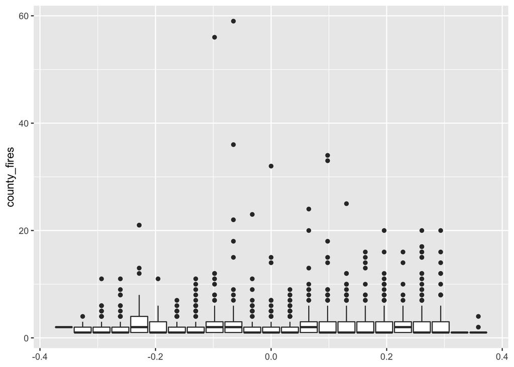

```r
fires_svi_binned %>%
  filter(!str_detect(county_fips, "NA")) %>%
  ggplot() +
  geom_boxplot(aes(y = county_fires, group = bucket))
```

## Typical cost of all fires

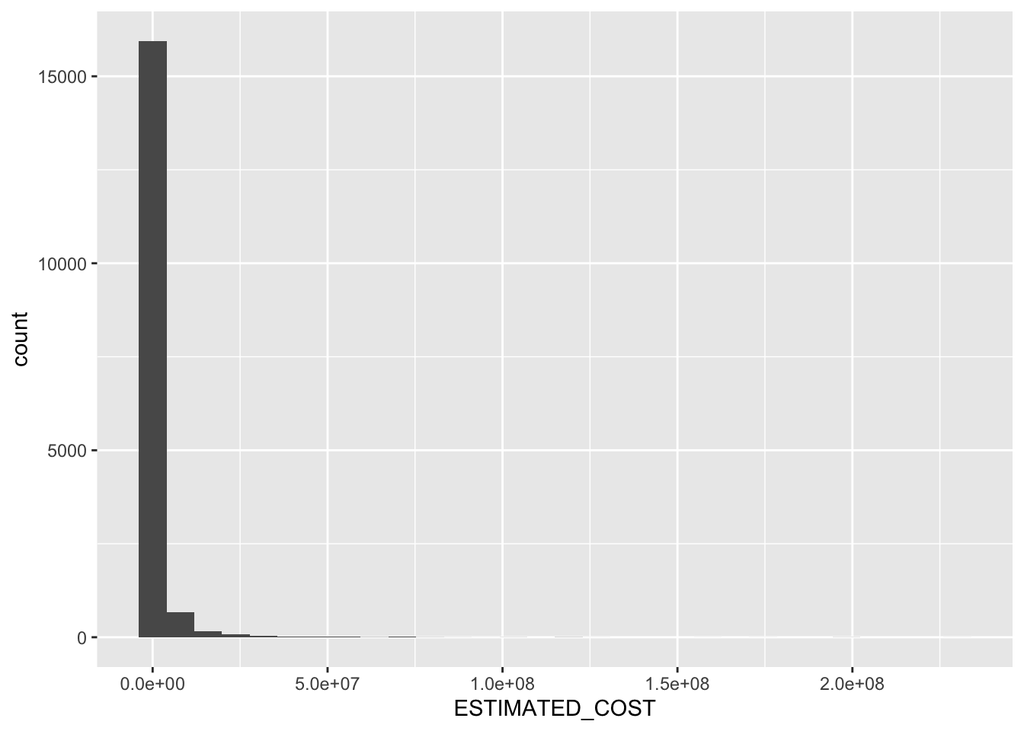

```r
sit209 %>%
  drop_na(ESTIMATED_COST) %>%
  ggplot() +
  geom_histogram(aes(ESTIMATED_COST))
```

## Typical cost of fires by bin

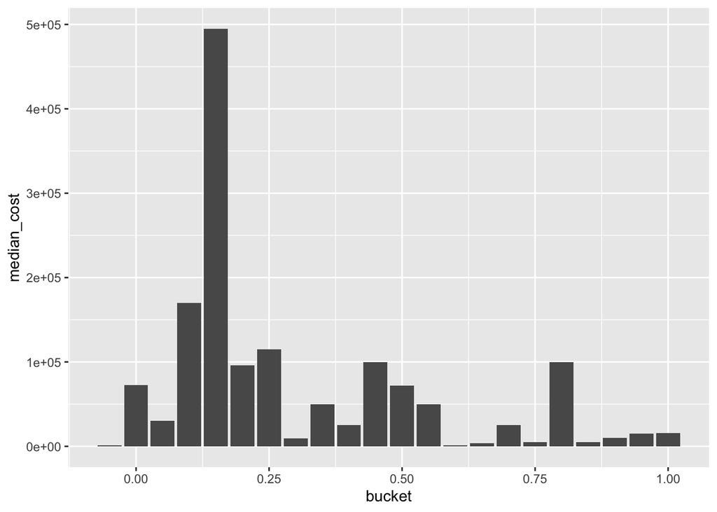

```r
fires_svi_binned %>%
  left_join(sit_karen_mtbs, by = c("year_fips")) %>%
  drop_na(ESTIMATED_COST, bucket) %>%
  group_by(bucket) %>%
  summarize(median_cost = median(ESTIMATED_COST)) %>%
  ggplot(aes(x = bucket, y = median_cost)) +
  geom_col(position = "dodge")
```

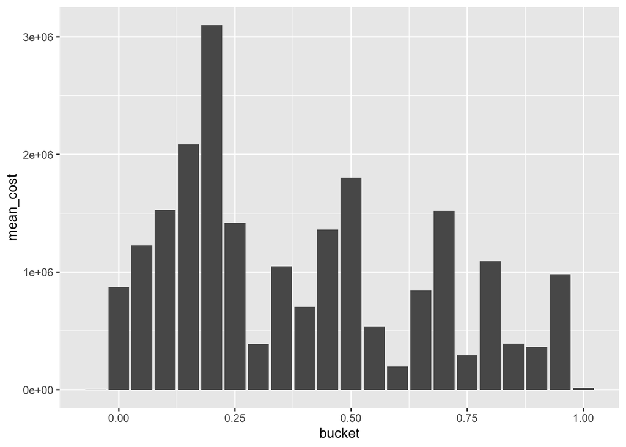

```r
fires_svi_binned %>%
  left_join(sit_karen_mtbs, by = c("year_fips")) %>%
  drop_na(ESTIMATED_COST, bucket) %>%
  group_by(bucket) %>%
  summarize(mean_cost = mean(ESTIMATED_COST)) %>%
  ggplot(aes(x = bucket, y = mean_cost)) +
  geom_col(position = "dodge")
```

## Ratio of cost per acre

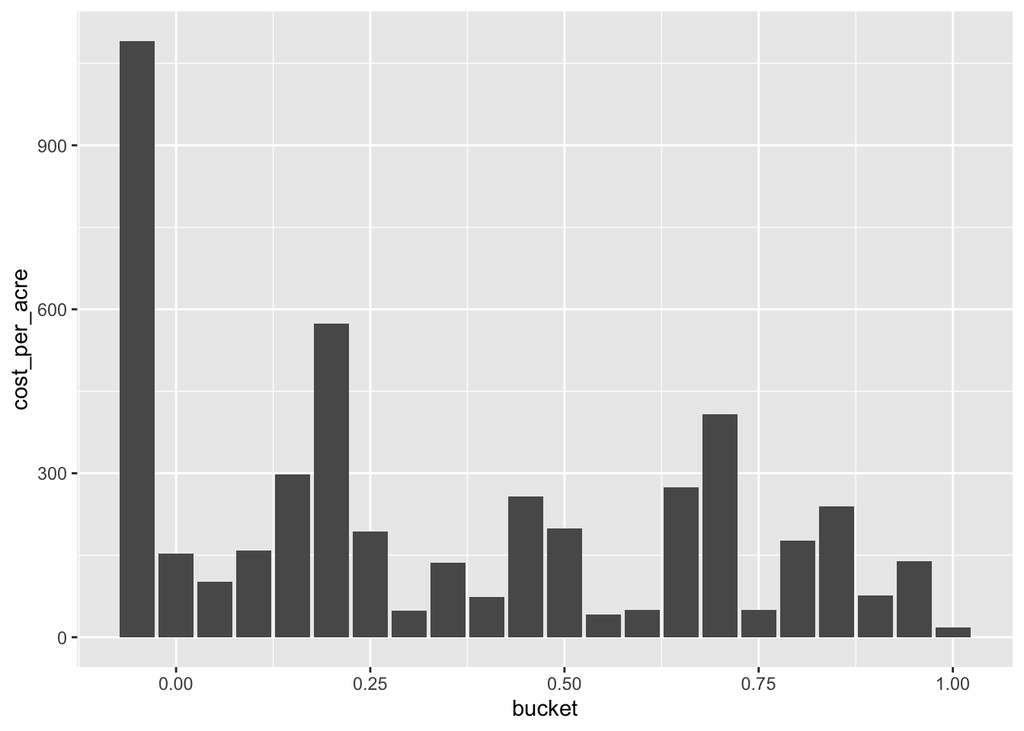

```r
fires_svi_binned %>%
  left_join(sit_karen_mtbs, by = c("year_fips")) %>%
  drop_na(bucket) %>%
  group_by(bucket) %>%
  summarize(
    cost = sum(ESTIMATED_COST, na.rm = TRUE),
    acres = sum(FIRE_SIZE, na.rm = TRUE)
  ) %>%
  filter(acres > 0) %>%
  mutate(cost_per_acre = cost / acres) %>%
  ggplot(aes(x = bucket, y = cost_per_acre)) +
  geom_col(position = "dodge")
```

## county_summary analysis

```
## geom_path: Each group consists of only one observation. Do you need to adjust
## the group aesthetic?
```

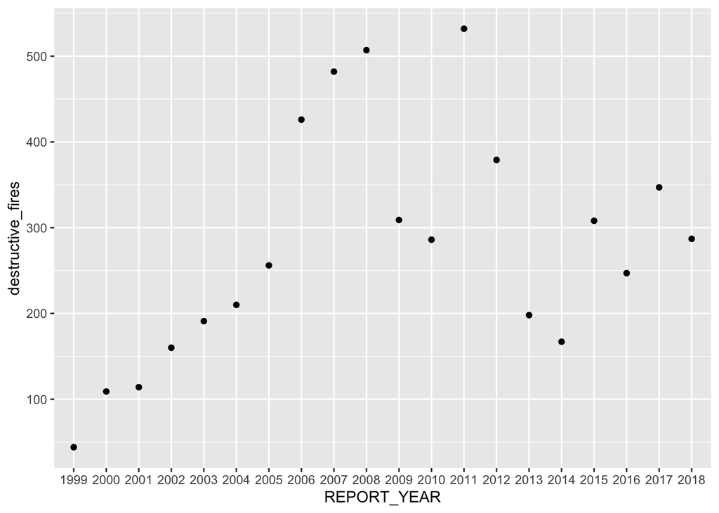

```r
county_summary %>%
  group_by(REPORT_YEAR) %>%
  summarize(destructive_fires = sum(destroyed_count)) %>%
  ggplot() +
  geom_point(aes(x = REPORT_YEAR, y = destructive_fires)) +
  geom_line(aes(x = REPORT_YEAR, y = destructive_fires))
```

```r
county_summary %>%
  group_by(county_fips) %>%
  summarize(destructive_fires = sum(destroyed_count)) %>%
  filter(!str_detect(county_fips, "NA")) %>%
  arrange(desc(destructive_fires))
```

```
## # A tibble: 1,675 x 2
##    county_fips destructive_fires
##    <chr>                   <int>
##  1 53007                      46
##  2 6105                       46
##  3 6063                       31
##  4 12105                      29
##  5 45075                      26
##  6 32007                      24
##  7 6065                       24
##  8 27115                      22
##  9 45025                      21
## 10 16039                      20
## # … with 1,665 more rows
```

```r
sit_karen_mtbs %>%
  filter(county_fips == "6105") # Trinity County California
```

```
## # A tibble: 121 x 90
##    REPORT_YEAR FORM_TYPE INTERNAL_DB_ID INCIDENT_NUMBER INCIDENT_NAME
##    <chr>       <chr>     <chr>          <chr>           <chr>
##  1 1999        a         <NA>           CA-RCC-4578     LOWDEN (CA-S…
##  2 2006        b         <NA>           CA-SRF-000999   PANTHER
##  3 2006        b         <NA>           CA-SHF-2120     PIGEON
##  4 2006        b         <NA>           CA-SHF-001693   BAR COMPLEX
##  5 2006        b         <NA>           CA-MNF-897      KINGSLEY COM…
##  6 2006        b         <NA>           CA-MNF-897      KINGSLEY COM…
##  7 2007        b         <NA>           CA-MNF-1050     YOLLA BOLLY …
##  8 2007        b         <NA>           CA-MNF-1050     YOLLA BOLLY …
##  9 2007        b         <NA>           CA-MNF-1050     YOLLA BOLLY …
## 10 2007        b         <NA>           CA-MNF-1050     YOLLA BOLLY …
## # … with 111 more rows, and 85 more variables: INCIDENT_TYPE <chr>,
## #   STATE.x <chr>, COUNTY.x <chr>, LATITUDE.x <dbl>, LONGITUDE.x <dbl>,
## #   START_DATE <chr>, END_DATE <chr>, CAUSE <chr>, ESTIMATED_COST <dbl>,
## #   REPORT_DATE <dttm>, MAX_PERSONNEL <dbl>, INCIDENT_AREA <dbl>,
## #   MAX_SFR_THREAT <dbl>, MAX_MFR_THREAT <dbl>, MAX_MU_THREAT <dbl>,
## #   MAX_COMM_THREAT <dbl>, MAX_OUTB_THREAT <dbl>, MAX_OTHER_THREAT <dbl>,
## #   SFR_DAMAGED <dbl>, MFR_DAMAGED <dbl>, MU_DAMAGED <dbl>, COMM_DAMAGED <dbl>,
## #   OTHER_DAMAGED <dbl>, SFR_DESTROYED <dbl>, MFR_DESTROYED <dbl>,
## #   MU_DESTROYED <dbl>, COMM_DESTROYED <dbl>, OUTB_DESTROYED <dbl>,
## #   OTHER_DESTROYED <dbl>, INJURIES <dbl>, FATALITIES <dbl>, REPORT_ID <chr>,
## #   WILDFIRE <lgl>, STATE_FIPS <chr>, DESTROYED <lgl>, THREATENED <lgl>,
## #   CLIMATE_REGION <chr>, OBJECTID <int>, FOD_ID <int>, FPA_ID <chr>,
## #   SOURCE_SYSTEM_TYPE <chr>, SOURCE_SYSTEM <chr>, NWCG_REPORTING_AGENCY <chr>,
## #   NWCG_REPORTING_UNIT_ID <chr>, NWCG_REPORTING_UNIT_NAME <chr>,
## #   SOURCE_REPORTING_UNIT <chr>, SOURCE_REPORTING_UNIT_NAME <chr>,
## #   LOCAL_FIRE_REPORT_ID <chr>, LOCAL_INCIDENT_ID <chr>, FIRE_CODE <chr>,
## #   FIRE_NAME <chr>, ICS_209_NAME <chr>, MTBS_ID <chr>, MTBS_FIRE_NAME <chr>,
## #   COMPLEX_NAME <chr>, FIRE_YEAR <int>, DISCOVERY_DATE <dbl>,
## #   DISCOVERY_DOY <int>, DISCOVERY_TIME <chr>, STAT_CAUSE_CODE <dbl>,
## #   STAT_CAUSE_DESCR <chr>, CONT_DATE <dbl>, CONT_DOY <int>, CONT_TIME <chr>,
## #   FIRE_SIZE <dbl>, FIRE_SIZE_CLASS <chr>, LATITUDE.y <dbl>,
## #   LONGITUDE.y <dbl>, OWNER_CODE <dbl>, OWNER_DESCR <chr>, STATE.y <chr>,
## #   COUNTY.y <chr>, FIPS_CODE <chr>, FIPS_NAME <chr>, Shape <blob>,
## #   county_fips <chr>, bin_year <dbl>, year_fips <glue>, Fire_Name <chr>,
## #   Year <dbl>, StartMonth <dbl>, StartDay <dbl>, Fire_Type <chr>, Acres <dbl>,
## #   geometry <MULTIPOLYGON [°]>
```